# (Gender) Diversity and Building Community in Data Science

Jenine K. Harris

R-Ladies St. Louis | Washington University in St. Louis

## Disclaimer

Data science is an emerging field, so research on “data science” is limited. Much of the evidence in this presentation focuses on the fields of computer science and math since they are (arguably) the foundational fields in data science.

## R-Ladies Global & R-Ladies St. Louis

- R-Ladies Global
  - Mission of **promoting gender diversity in the R community**
  - 138 cities in 44 countries with 39,676 members
- R-Ladies STL
  - hosts 4-5 Meetups a year
  - Hands-on workshops data science topics using R (e.g., intro, graphing, rcpp)
  - About 20-25 attendees per Meetup
  - Sponsored by Net Effects and Microsoft

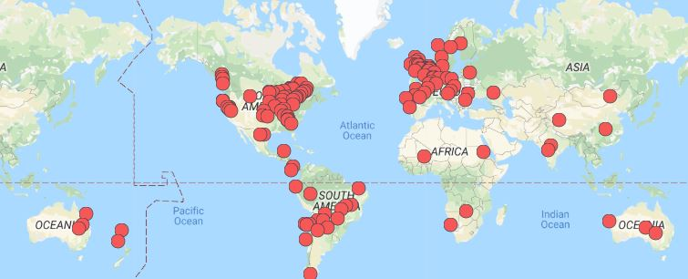

## So why do we need R-Ladies?

…because although women who choose data science are satisfied with their career:

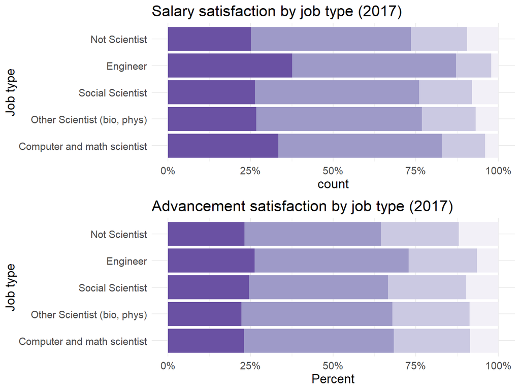

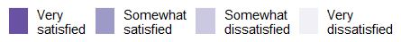

## Few women choose data science

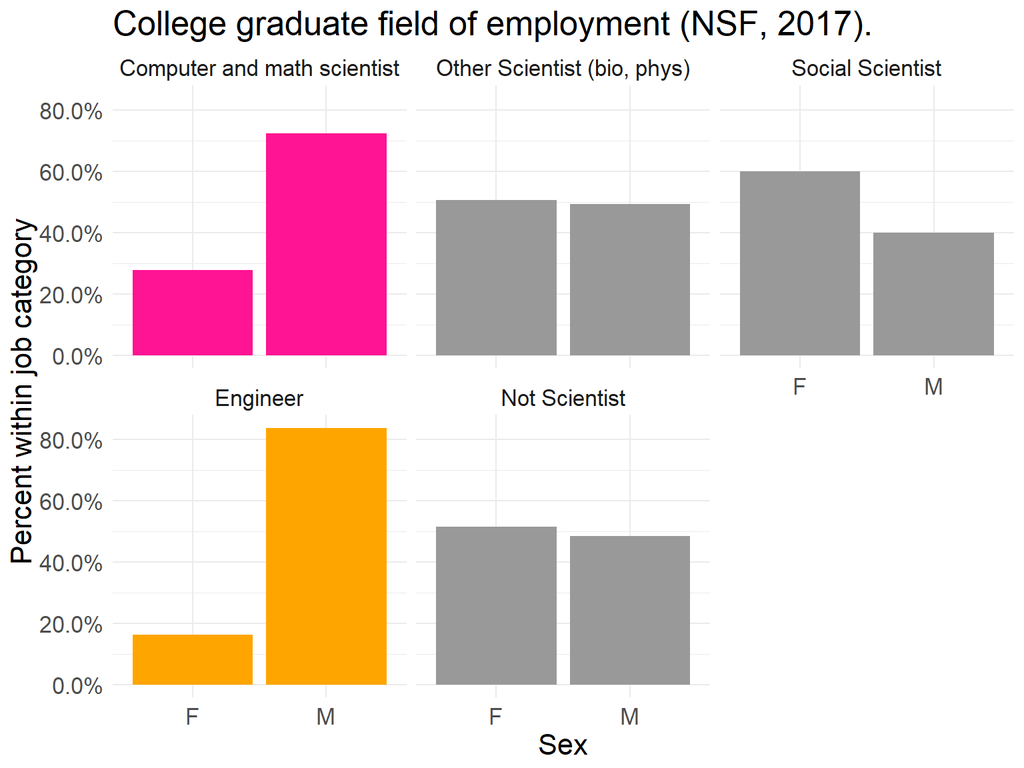

## And the gap is widening

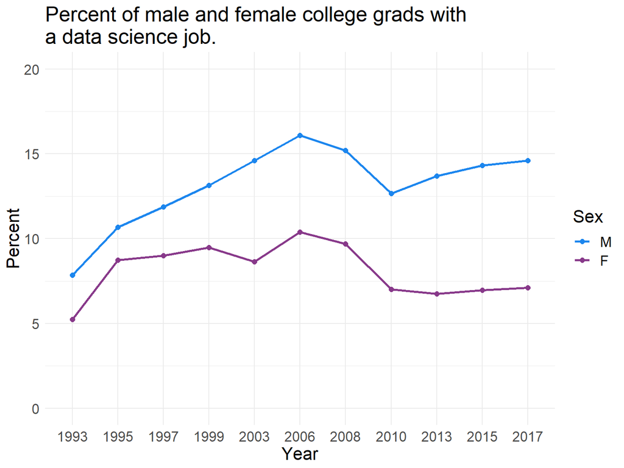

## Or (at best) staying the same

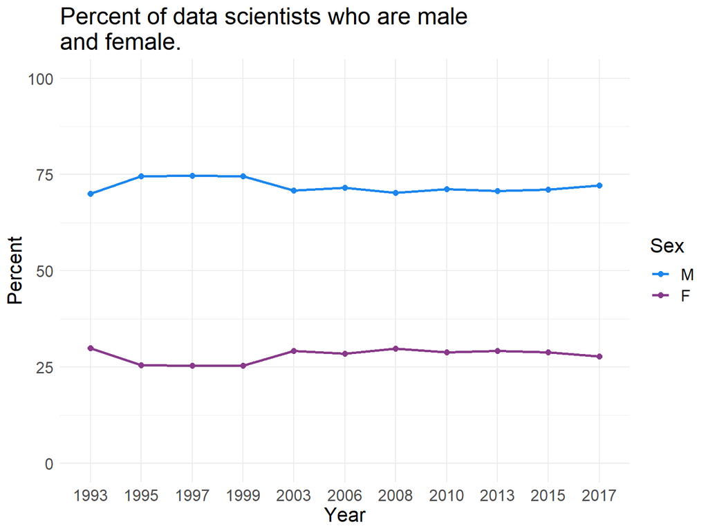

## After graphing those data, first I was like…

[figure not shown]

## Then I was like…

[figure not shown]

## Explanations in the scientific literature

- biological: natural/innate ability
- social-cultural: societal and cultural norms (e.g., stereotypes)
- structural: institutional barriers

## Biological: Males are innately better at math & computers (debunked)

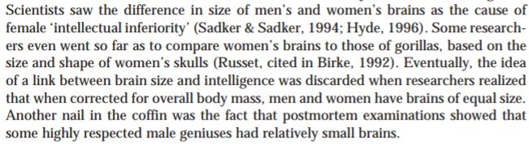

## Biological: Seriously?

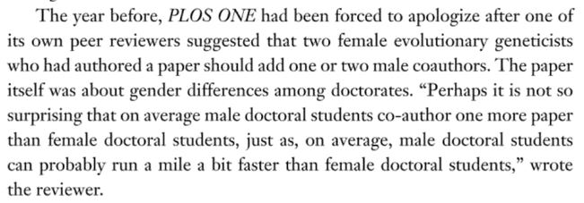

## And again I was like…

[figure not shown]

## Social-cultural: Male and female students perceive “computer people” and math as male

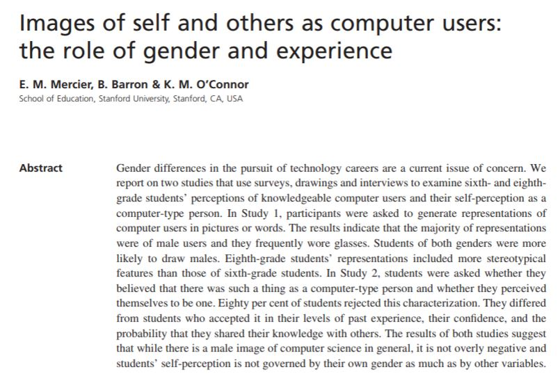

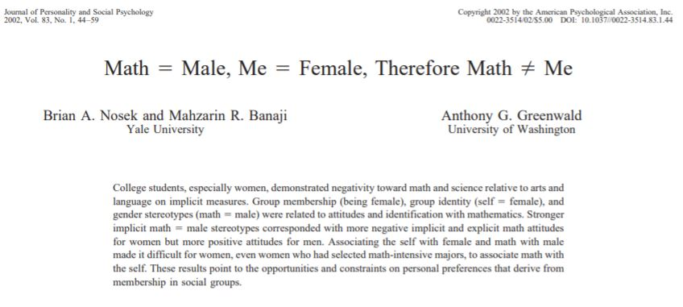

## Social-cultural: Stereotype threat reduces math scores for female students

- “When women perform math, unlike men, they risk being judged by the negative stereotype that women have weaker math ability. We call this predicament stereotype threat…” ~ Spencer et al., 1999

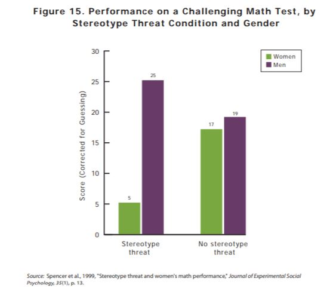

## Structural: Elementary teachers believe boys are better than girls at math

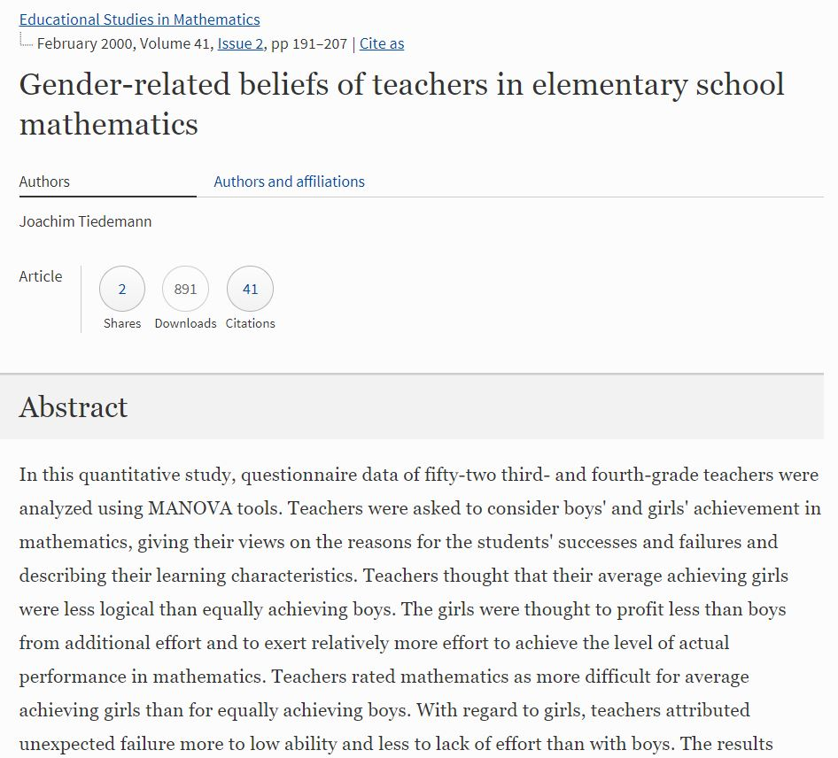

## Structural: Et tu, professor?

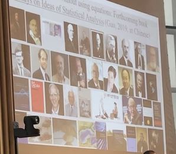

## Structural: Companies hire males over females given same qualifications

[figure not shown]

## ….and then there were fewer women in data science

[figure not shown]

## Lame. How do we get out of this mess?

[figure not shown]

## We can be visible (or help others be visible)

[figure not shown]

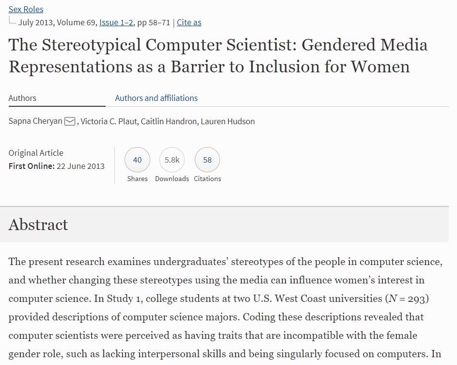

## We can be and seek role models (or connect others with role models)

[figure not shown]

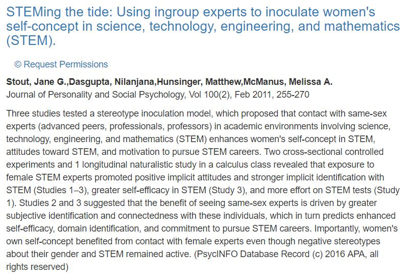

## We can teach about stereotype threat and use counter-stereotypes

[figure not shown]

## Basically, we can create a visible community of and for women in data science

[figure not shown]

## Nobody can do everything, but everyone can do something

- Evidence-based things you can do:
  - Be visible (or assist others in being visible)
  - Teach about stereotype threat
  - Use counter-stereotypes
  - Be/seek role models (or assist others in seeking role models)

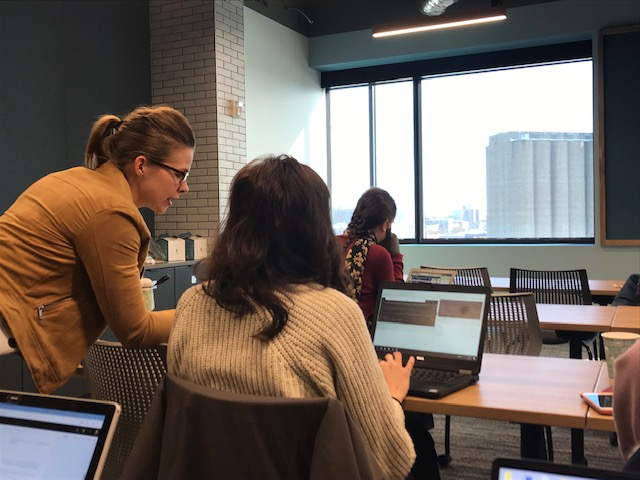

## And we don’t have to do it alone

- Local groups specifically focused on / supporting gender diversity in data science:
  - R-Ladies St. Louis
  - Women in Data Science St. Louis
  - St. Louis Women in Tech Exchange
- Ally groups:
  - St. Louis R Users
  - St. Louis Machine Learning & Data Science
  - 500 Women Scientists St. Louis

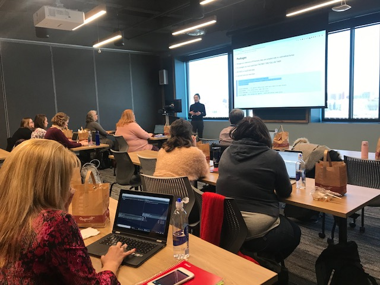

## Thank you!

[figure not shown]